# Análise de Dados de Transcriptômica Espacial

## Associar comunicação às arestas

```r
arestas <- gs@edges %>% select(name1, name2)

arestas_direcionadas <- bind_rows(
  arestas,
  arestas %>% transmute(name1 = name2, name2 = name1)
) %>%
  distinct()

spotCom_dt <- arestas_direcionadas %>%
  inner_join(
    spot.to.spot.communication %>% filter(sample == nome_imagem),
    by = c("name1" = "source_spot", "name2" = "target_spot")
  )

spotCom_dt$arrowType <- 1

interacoes_disponiveis <- spotCom_dt %>%
  select(ligand, receptor, interaction_name) %>%
  filter(!is.na(ligand), !is.na(receptor)) %>%
  distinct()

head(interacoes_disponiveis)
```

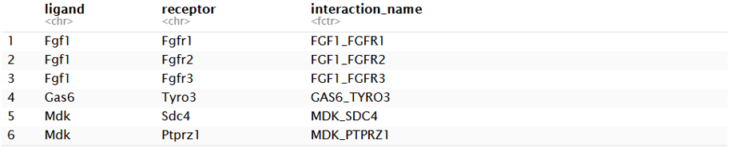

Interações ligante–receptor disponíveis na rede espacial.

## Função de projeção espacial

```r
communication_pathwayspace <- function(gs, lig, recep, spotCom_dt) {
  comunicacoes <- spotCom_dt %>% filter(ligand == lig, receptor == recep)

  spots_selecionados <- unique(c(comunicacoes$name1, comunicacoes$name2))

  gs_selecionado <- gs_subset_nodes(gs, spots_selecionados)
  pspace_obj <- buildPathwaySpace(gs_selecionado)

  distancia_spots <- getNearestNode(pspace_obj)
  pdist <- mean(distancia_spots$dist)

  pspace_obj <- silhouetteMapping(pspace_obj, baseline = 0.1)

  resolver_features <- function(rotulo, features_disponiveis) {
    if (rotulo %in% features_disponiveis) {
      return(rotulo)
    }

    componentes <- strsplit(rotulo, "_", fixed = TRUE)[[1]]
    features_disponiveis[match(tolower(componentes),
      tolower(features_disponiveis))]
  }

  features_disponiveis <- colnames(pspace_obj@fdata)
  features_ligante <- resolver_features(lig, features_disponiveis)
  features_receptor <- resolver_features(recep, features_disponiveis)

  if (anyNA(c(features_ligante, features_receptor))) {
    stop("O ligante ou o receptor não foi encontrado nos dados de expressão.")
  }

  sinal_ligante <- rowSums(as.matrix(
    pspace_obj@fdata[, features_ligante, drop = FALSE]))
  sinal_receptor <- rowSums(as.matrix(
    pspace_obj@fdata[, features_receptor, drop = FALSE]))

  vertexSignal(pspace_obj) <- sinal_ligante + sinal_receptor

  pspace_obj <- circularProjection(
    pspace_obj, decay.fun = weibullDecay(decay = 0.5, pdist = pdist),
    aggregate.fun = signalAggregation("wmean"),
    k = gs_vcount(pspace_obj))

  pspace_obj
}
```

## PathwaySpace: Fgf1–Fgfr1

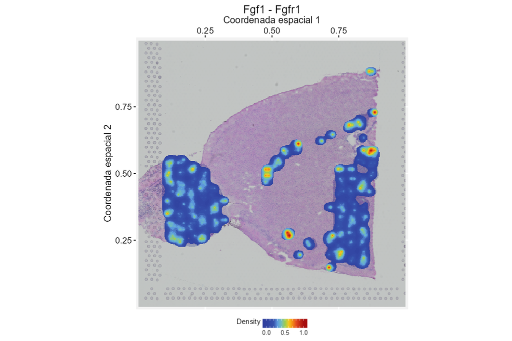

```r
pspace_obj <- communication_pathwayspace(
  gs = gs, lig = "Fgf1", recep = "Fgfr1",
  spotCom_dt = spotCom_dt)

grafico_exemplo <- ggplot(pspace_obj) +
  annotation_gspace_image(pspace_obj) +
  annotation_pspace_signal(pspace_obj, si.alpha = 0.25) +
  spatial_theme + labs(title = "Fgf1 - Fgfr1")

grafico_exemplo
```

## PathwaySpace: Fgf1–Fgfr2

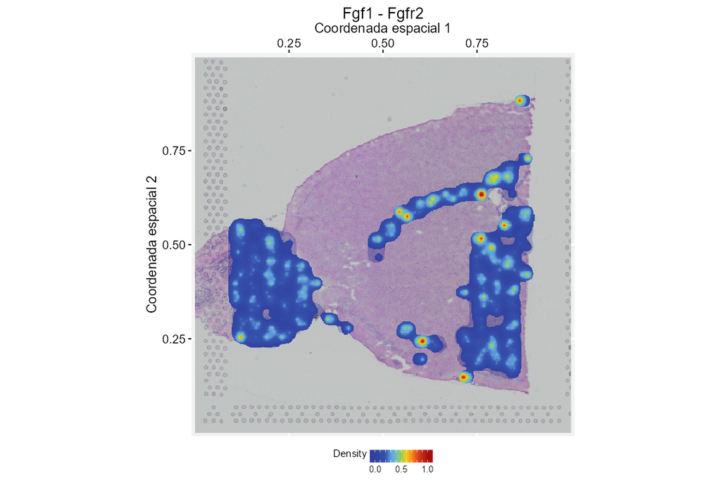

```r
pspace_obj <- communication_pathwayspace(
  gs = gs, lig = "Fgf1", recep = "Fgfr2",
  spotCom_dt = spotCom_dt)

grafico_exemplo <- ggplot(pspace_obj) +
  annotation_gspace_image(pspace_obj) +
  annotation_pspace_signal(pspace_obj, si.alpha = 0.25) +
  spatial_theme + labs(title = "Fgf1 - Fgfr2")

grafico_exemplo
```

## PathwaySpace: Fgf1–Fgfr3

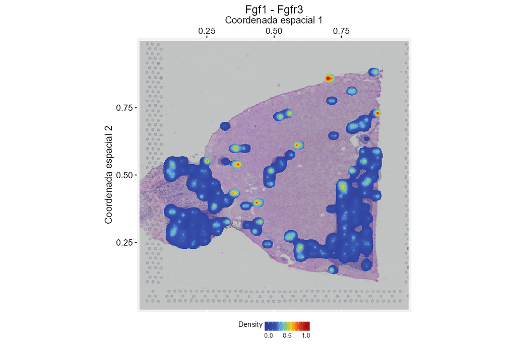

```r
pspace_obj <- communication_pathwayspace(
  gs = gs, lig = "Fgf1", recep = "Fgfr3",
  spotCom_dt = spotCom_dt)

grafico_exemplo <- ggplot(pspace_obj) +
  annotation_gspace_image(pspace_obj) +
  annotation_pspace_signal(pspace_obj, si.alpha = 0.25) +
  spatial_theme + labs(title = "Fgf1 - Fgfr3")

grafico_exemplo
```

## Comparação entre receptores de Fgf1

- O ligante é o mesmo, mas a distribuição espacial muda com o receptor.
- Fgfr1 e Fgfr2 formam domínios projetados mais extensos.
- Fgfr3 produz uma paisagem mais descontínua, com focos separados.

> A projeção descreve onde a interação é compatível com a rede espacial e com a expressão observada. Ela não demonstra fluxo molecular direto entre células.

## Desafio

**Repita a análise usando tipos celulares inferidos pelo RCTD no lugar dos clusters do Seurat.**

Vinheta anterior: deconvolução com RCTD

# Segmentação celular em Visium HD

Vinheta de referência: **segmentação celular em Visium HD**

## Visium HD

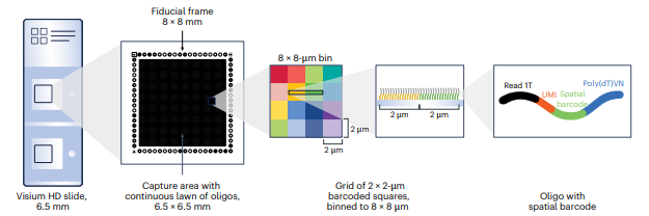

A captura de áreas maiores preserva o contexto do tecido.

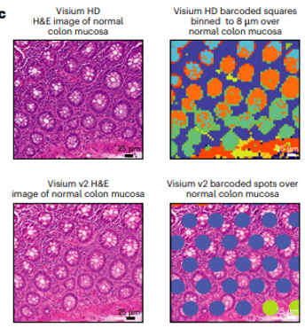

A resolução de 2 µm permite reagrupar bins em diferentes escalas.

## De bins a células

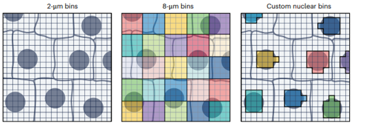

Segmentação e agregação dos bins no limite celular.

## Exemplo de aplicação

[figure not shown]

Populações imunes em câncer colorretal analisadas com Visium HD. Fonte: Oliveira et al. (2025) (Oliveira et al. 2025).

## Objetivo da prática

- Inspecionar geometrias celulares já estimadas.
- Representar cada célula como centro e como polígono.
- Comparar expressão discreta e sinal espacial contínuo.
- Integrar RGraphSpace, sf e PathwaySpace.

## Pacotes

```r
library("RGraphSpace")
library("sf")
library("ggplot2")
library("patchwork")
library("PathwaySpace")
```

## Carregar o objeto preparado

```r
arquivo_dados <- file.path(diretorio_dados, "VisiumHD_GS_Crop.RDS")

gs_crop <- readRDS(arquivo_dados)

if (!inherits(gs_crop, "GraphSpace")) {
  stop("O arquivo baixado não contém um objeto da classe GraphSpace.")}

gs_crop
```

```
A GraphSpace-class object for:
IGRAPH bb1dc4c UN-- 539 0 --
+ attr: x (v/n), y (v/n), name (v/c), nodeLabel (v/c), nodeSize (v/n), sample_id (v/c),
| arrowType (e/c)
+ node payload: 2 (map, cellseg)
+ features: 18132 (SAMD11, NOC2L, KLHL17, PLEKHN1, ...)
+ samples: 539 (cellid_000127405-1, cellid_000127406-1, ...)
+ node spatial boundaries: normalized to image space
| x: [4433, 4512] -> [0, 1] (cols)
| y: [1120, 1199] -> [0, 1] (rows)
+ image spatial boundaries: cropped to graph space
| x: [1, 6000] -> [1, 80] (cols)
| y: [1, 3886] -> [1, 80] (rows)
```

## Geometrias celulares

```r
gs_crop@nodes$cellseg
```

[output not shown]

```r
geometrias_celulares <- gs_crop@nodes$cellseg

length(geometrias_celulares)
```

```
[1] 539
```

```r
sf::st_geometry_type(geometrias_celulares) |> table()
```

```
          GEOMETRY              POINT         LINESTRING            POLYGON         MULTIPOINT
                 0                  0                  0                532                  0
   MULTILINESTRING       MULTIPOLYGON GEOMETRYCOLLECTION     CIRCULARSTRING      COMPOUNDCURVE
                 0                  7                  0                  0                  0
      CURVEPOLYGON         MULTICURVE       MULTISURFACE              CURVE            SURFACE
                 0                  0                  0                  0                  0
 POLYHEDRALSURFACE                TIN           TRIANGLE
                 0                  0                  0
```

## Células individuais

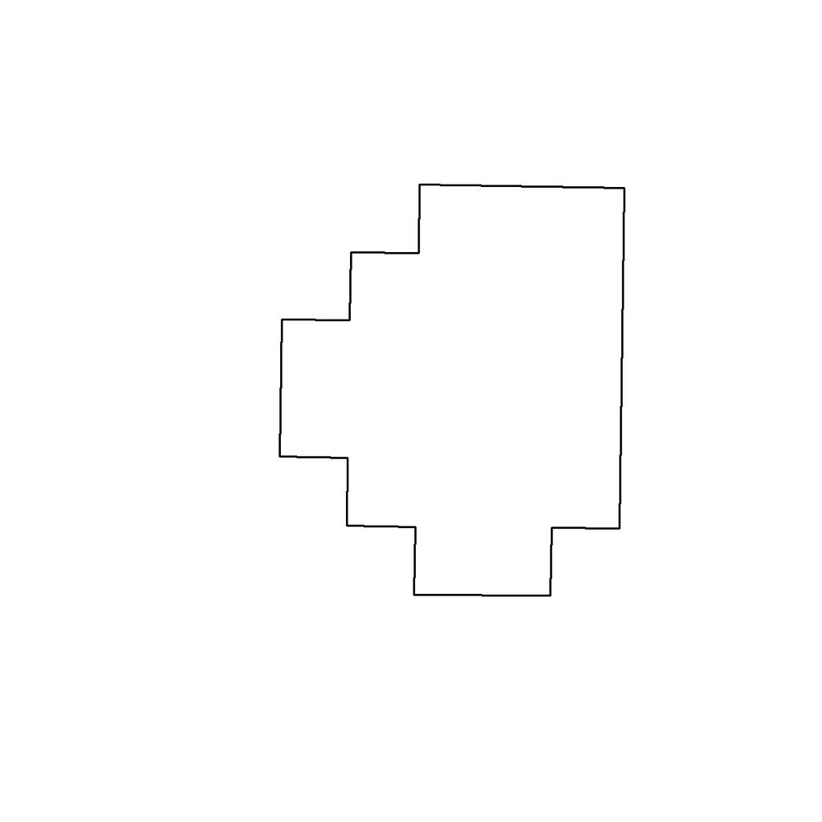

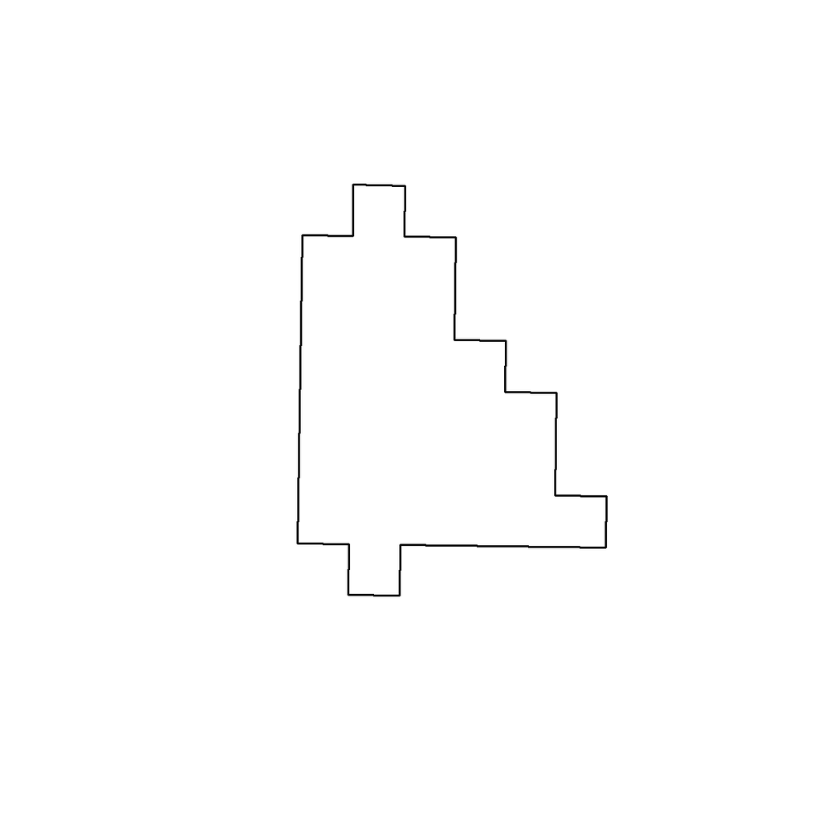

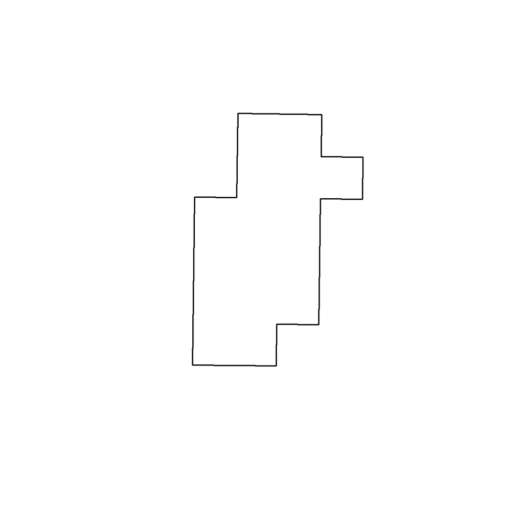

```r
plot(gs_crop@nodes$cellseg[1])
plot(gs_crop@nodes$cellseg[2])
plot(gs_crop@nodes$cellseg[3])
```

## Primeiras vinte geometrias

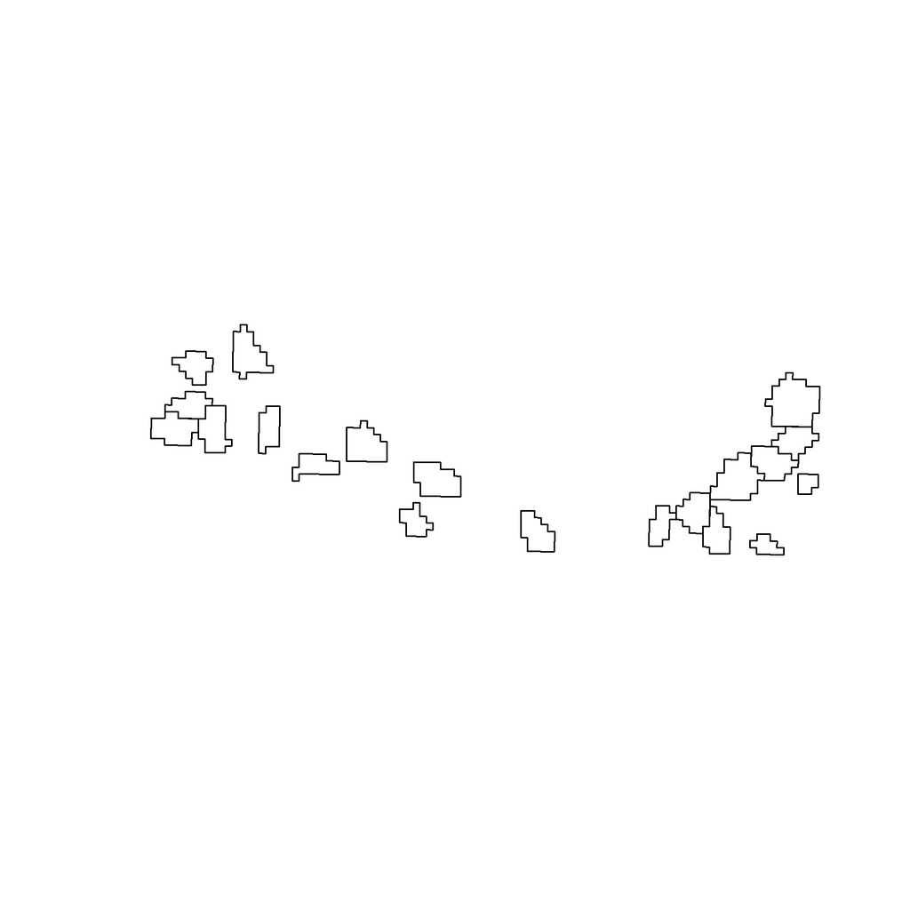

```r
plot(st_combine(gs_crop@nodes$cellseg[1:20]))
```

## Escala comum para PIGR

```r
cpal <- hcl.colors(100, palette = "Geyser", rev = FALSE)
data_range <- range(log2(gs_crop[["fdata"]] + 1))
```

A mesma transformação, paleta e limites serão usados nos painéis seguintes.

## Limites sobre a imagem

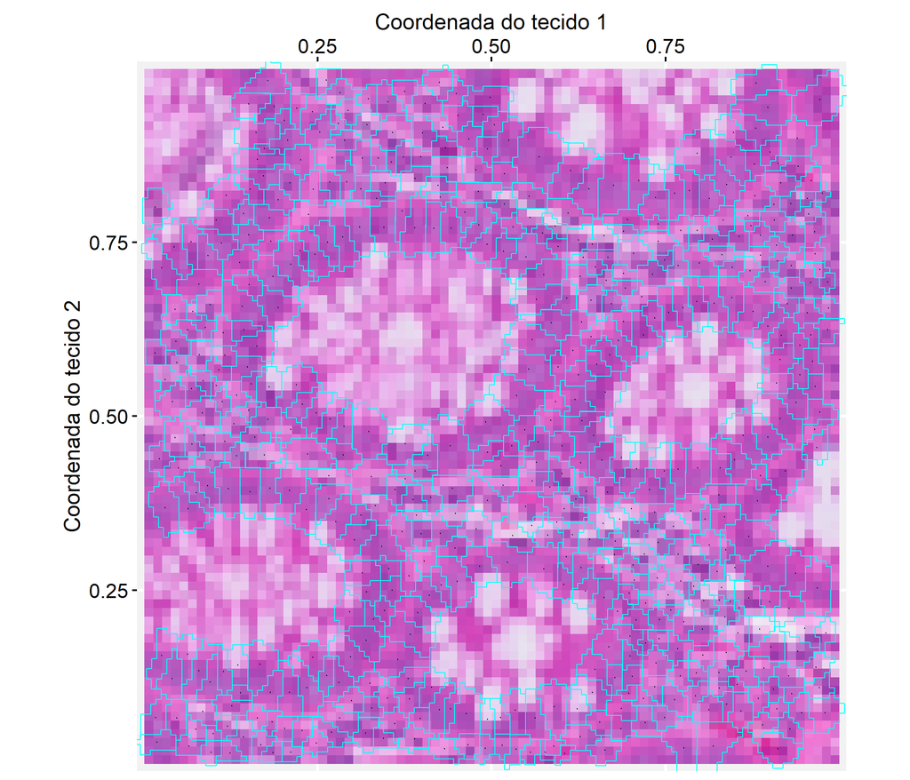

```r
p_nodes <- ggplot(gs_crop) +
  annotation_gspace_image(gs_crop, opacity = 1) +
  geom_sf( aes(geometry = cellseg), fill = NA,
    linewidth = 0.3, colour = "cyan") +
  geom_nodespace(colour = "black", size = 0.1, pch = 19) +
  scale_fill_continuous(palette = cpal, limits = data_range) +
  theme_gspace_coords(
    theme = "th3",is_norm = TRUE,
    xlab = "Coordenada do tecido 1",
    ylab = "Coordenada do tecido 2")
p_nodes
```

## Células como vértices

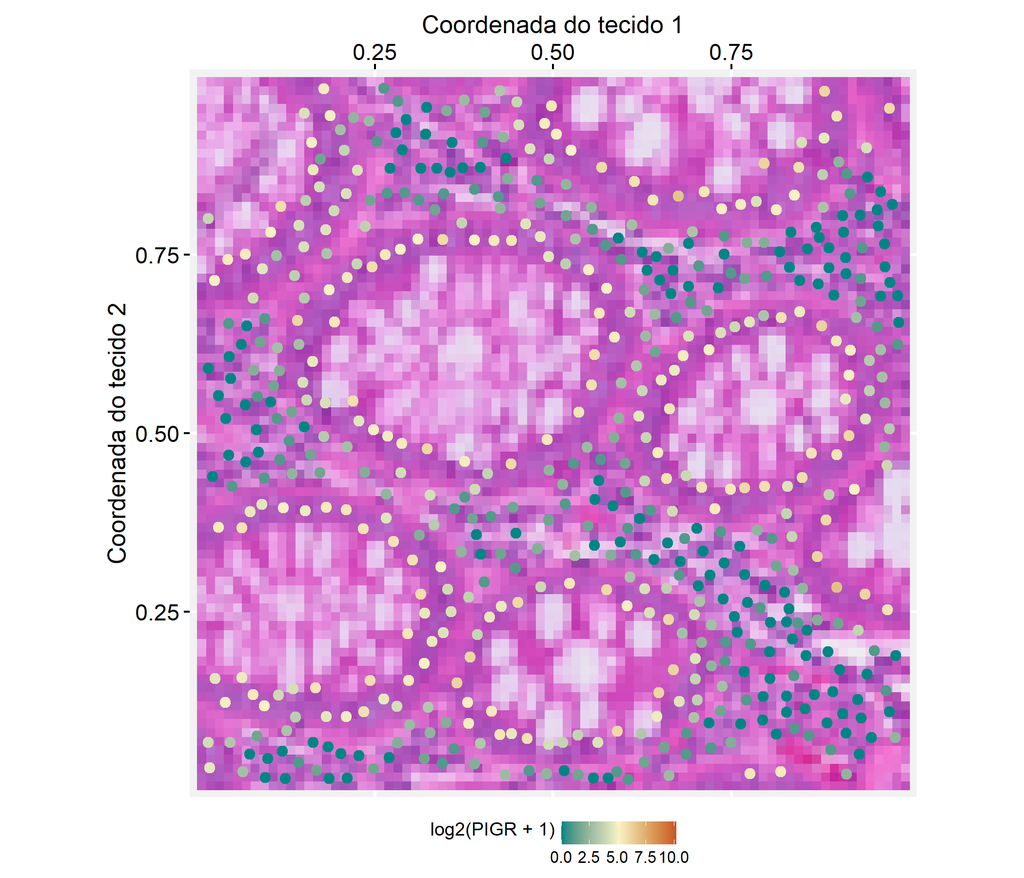

```r
p1 <- ggplot(gs_crop) +
  annotation_gspace_image(gs_crop, opacity = 1) +
  geom_nodespace(
    mapping = aes(colour = log2(PIGR + 1)),
    size = 1.5,pch = 19) +
  scale_colour_continuous(palette = cpal, limits = data_range) +
  theme_gspace_coords(
    theme = "th3",is_norm = TRUE,
    xlab = "Coordenada do tecido 1",
    ylab = "Coordenada do tecido 2")

p1
```

## Células como polígonos

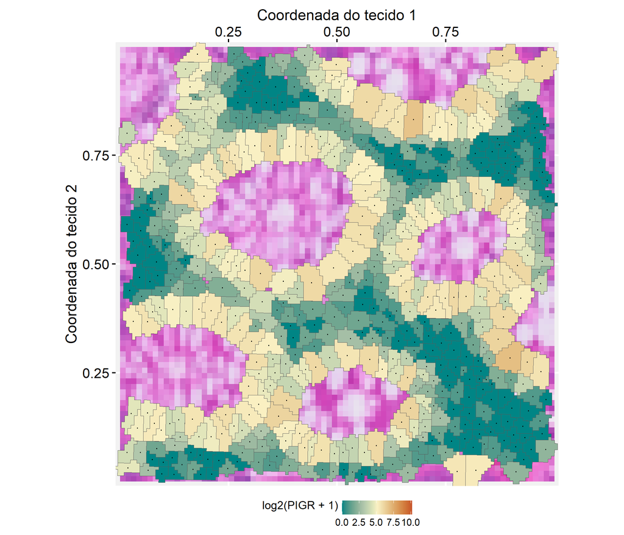

```r
p2 <- ggplot(gs_crop) +
  annotation_gspace_image(gs_crop, opacity = 1) +
  geom_sf(
    mapping = aes(
      geometry = cellseg,
      fill = log2(PIGR + 1))) +
  scale_fill_continuous(palette = cpal, limits = data_range) +
  geom_nodespace(colour = "black", size = 0.2, pch = 19) +
  theme_gspace_coords(
    theme = "th3",is_norm = TRUE,
    xlab = "Coordenada do tecido 1",
    ylab = "Coordenada do tecido 2")

p2
```

## Centros e polígonos

```r
p <- p1 + p2 +
  patchwork::plot_annotation(
    title = "Integração do RGraphSpace com geometrias sf",
    theme = theme(plot.title = element_text(hjust = 0.5)))
p
```

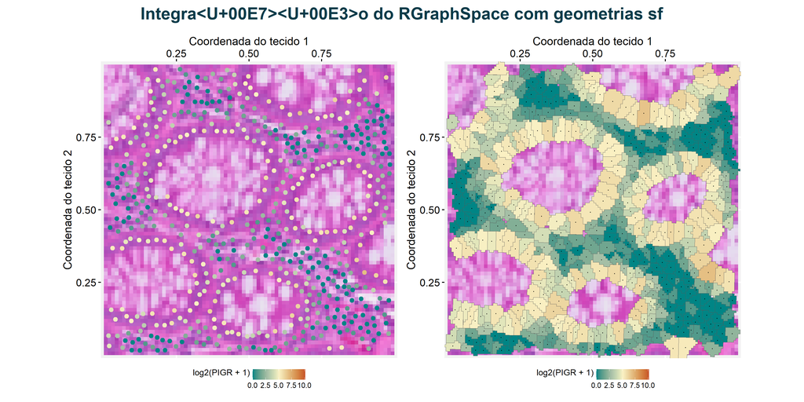

## Construir o PathwaySpace

```r
pspace_obj <- buildPathwaySpace(gs_crop, nrc = 700)

nspot <- getNearestNode(pspace_obj)
pdist <- mean(nspot$dist) # distância média
pdist
```

```
[1] 0.02754154
```

## Silhueta de projeção

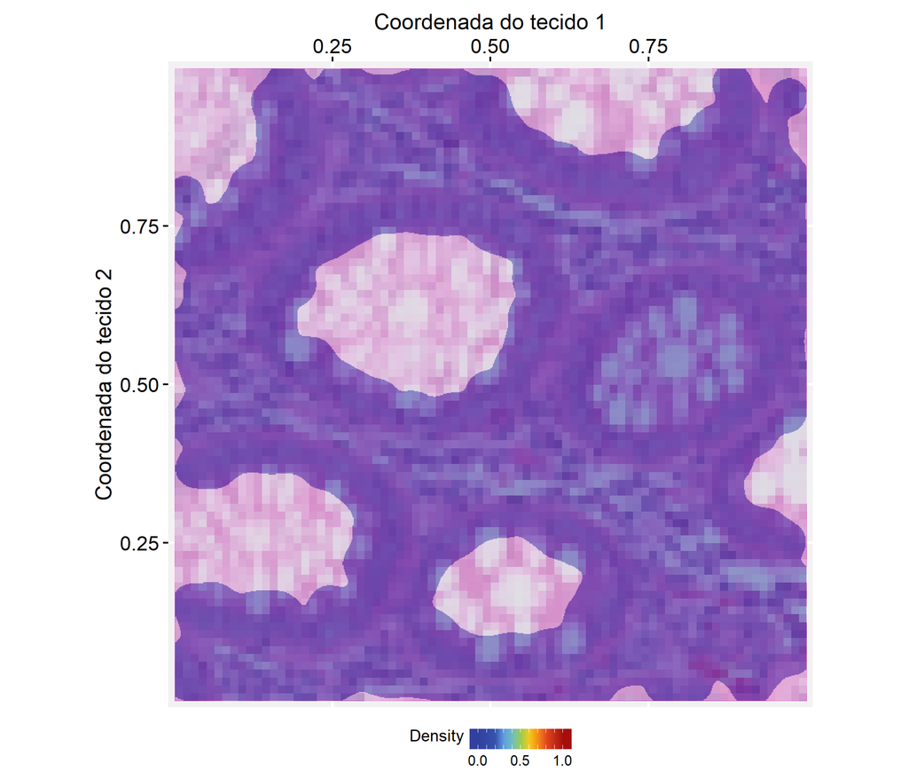

```r
pspace_obj <- silhouetteMapping(pspace_obj, fill.cavity = FALSE, baseline = 0.03, pdist = max(nspot$dist))

ggplot(pspace_obj) +
  annotation_gspace_image(pspace_obj) +
  annotation_pspace_signal(pspace_obj, si.alpha = 0.5) +
  theme_gspace_coords(
    theme = "th3",is_norm = TRUE,
    xlab = "Coordenada do tecido 1",
    ylab = "Coordenada do tecido 2")
```

## Projetar PIGR

```r
activeFeature(pspace_obj) <- "PIGR"

pspace_obj <- circularProjection(pspace_obj, k = gs_vcount(pspace_obj),
                                 decay.fun = weibullDecay(decay=0.5, pdist = pdist))
```

## Polígono e sinal contínuo

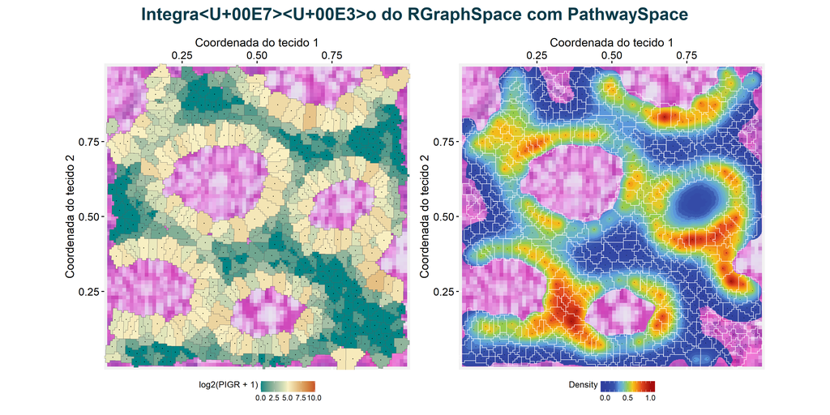

```r
p3 <- ggplot(pspace_obj) +
  annotation_gspace_image(pspace_obj) +
  annotation_pspace_signal(pspace_obj, si.alpha = 0, title = "") +
  geom_sf(
    aes(
      geometry = cellseg
    ),
    alpha = 0,
    linewidth = 0.3,
    colour = "white"
  ) +
  geom_nodespace(
    colour = "black",
    size = 0.1,
    pch = 19
  ) +
  theme_gspace_coords(
    theme = "th3",is_norm = TRUE,
    xlab = "Coordenada do tecido 1",
    ylab = "Coordenada do tecido 2")

p_comp <- p2 + p3 +
  patchwork::plot_annotation(
    title = "Integração do RGraphSpace com PathwaySpace",
    theme = theme(plot.title = element_text(hjust = 0.5)))
p_comp
```

## Leitura da comparação

- Os vértices resumem a posição de cada célula.
- Os polígonos preservam forma e área.
- A projeção contínua distribui o sinal entre os centros.
- O GraphSpace mantém expressão, posição e geometria alinhadas (Carazza-Kessler et al. 2026).

# Referências e análises downstream

## Anotação de tipos celulares

| Método | Pergunta central | Referência |
| --- | --- | --- |
| RCTD | quais tipos compõem cada spot? | Cable et al. (2022) |
| cell2location | qual abundância espacial de tipos finos? | Kleshchevnikov et al. (2022) |

Os dois métodos dependem de uma referência anotada e de compatibilidade entre a referência e o tecido.

## Genes espacialmente variáveis

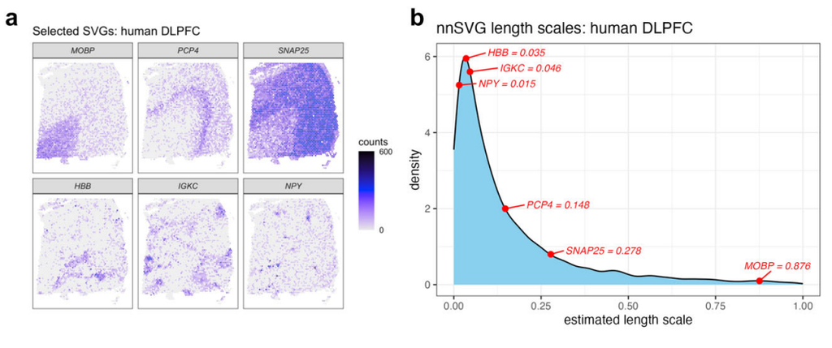

Genes selecionados e escalas espaciais estimadas pelo nnSVG. Fonte: Weber et al. (2023).

- SpatialDE modela padrões espaciais com processos gaussianos (Svensson, Teichmann, e Stegle 2018).
- nnSVG usa aproximações por vizinhos para ganhar escala (Weber et al. 2023).
- SPARK-X testa padrões espaciais sem um modelo paramétrico rígido (Zhu, Sun, e Zhou 2021).

## Microambientes teciduais

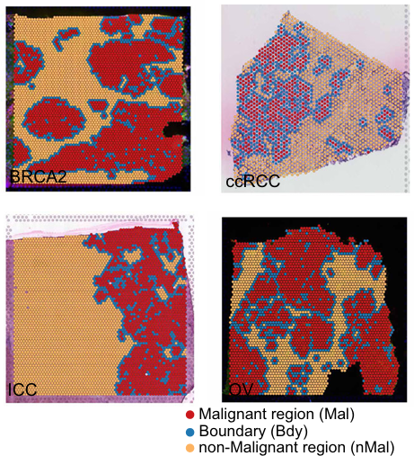

Compartimentos maligno, de borda e não maligno em diferentes tecidos. Fonte: Xun et al. (2023).

## Modelos de microambientes

- NCEM modela comunicação em grafos celulares (Fischer, Schaar, e Theis 2023).
- Cottrazm reconstrói o microambiente tumoral ao longo do eixo maligno, borda e não maligno (Xun et al. 2023).

## Ecossistemas integrados

**Squidpy**

- grafos espaciais, estatísticas de vizinhança e imagens;
- integração com o ecossistema Scanpy (Palla et al. 2022).

**Giotto**

- visualização, domínios, vizinhanças e comunicação;
- fluxo integrado para dados espaciais (Dries et al. 2021).

## Alinhamento e reconstrução 3D

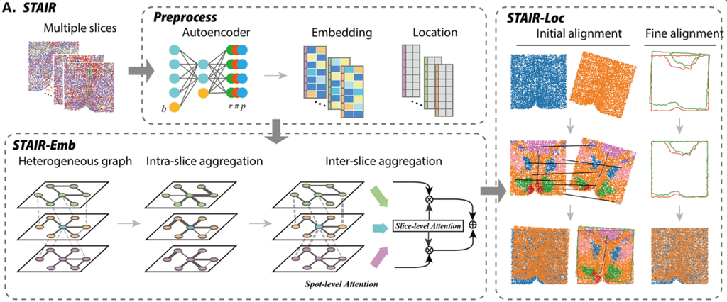

Arquitetura do STAIR para alinhamento, integração e reconstrução de fatias.

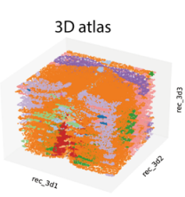

Atlas 3D reconstruído.

STAIR combina alinhamento espacial e integração entre fatias (Yu e Xie 2025).

## Do 3D ao 4D

[figure not shown]

Perspectiva sobre tecnologias espaciais e temporais para perfilamento 4D.

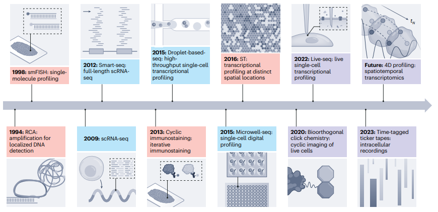

Linha do tempo de tecnologias que combinam posição e tempo.

O 4D incorpora dinâmica temporal à reconstrução espacial (Reynolds et al. 2025).

## Comparar plataformas antes do experimento

[figure not shown]

Comparação sistemática de métodos de transcriptômica espacial baseados em sequenciamento.

A escolha depende de resolução, área, sensibilidade, compatibilidade com histologia e custo (You et al. 2024).

## Guia prático de decisão

| Pergunta | Unidade de análise | Famílias de métodos |
| --- | --- | --- |
| composição celular | spot ou célula | RCTD, cell2location |
| padrão espacial de genes | gene e coordenadas | SpatialDE, nnSVG, SPARK-X |
| nichos e microambientes | grafo espacial | NCEM, Cottrazm |
| ecossistema completo | objeto multimodal | Squidpy, Giotto |
| reconstrução entre cortes | fatia e volume | STAIR |
| dinâmica espaço-temporal | tecido ao longo do tempo | perfilamento 4D |

## Fronteiras da área

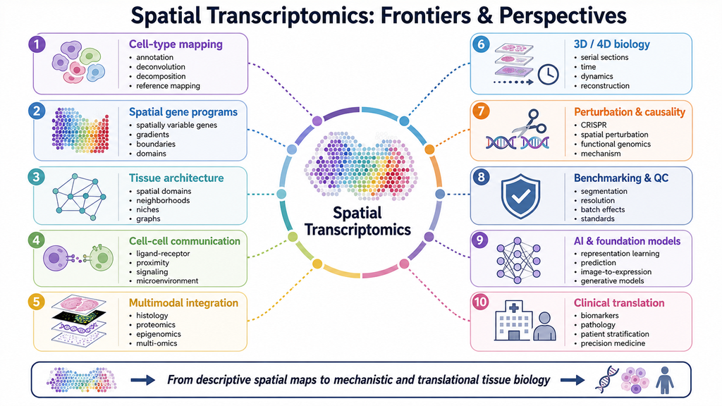

Síntese de perspectivas futuras. Ilustração gerada por IA no material PowerPoint original e usada aqui como mapa conceitual, não como evidência científica.

## Leituras recomendadas

Material complementar do curso:

flaviogckessler.github.io/CursoST_EscolaOmicas/apresentacoes/LEITURA_RECOMENDADA.html

Priorize a leitura da documentação do método, do artigo original e de benchmarks independentes.

## Créditos

SysbioLab, Laboratório de Bioinformática e Biologia de Sistemas, UFPR

- Prof. Dr. Mauro Antônio Alves Castro
- Jonathan André Back
- Lana Bazan Peters Querne
- Flávio Gabriel Carazza-Kessler

github.com/sysbiolab  
bioinfo.ufpr.br

## Obrigado

Dúvidas?

## Referências citadas

Cable, Dylan M., Evan Murray, Luli S. Zou, Aleksandr Goeva, Evan Z. Macosko, Fei Chen, e Rafael A. Irizarry. 2022. “Robust decomposition of cell type mixtures in spatial transcriptomics”. *Nature Biotechnology* 40 (4): 517–26. https://doi.org/10.1038/s41587-021-00830-w.

Carazza-Kessler, Flávio Gabriel, Jonathan André Back, Lana Bazan Peters Querne, Victor Henrique Apolonio dos Santos, e Mauro Antônio Alves Castro. 2026. “RGraphSpace: Rendering graphs as coherent spatial objects in ggplot2”. *Journal of Open Source Software* 11 (126): 11209. https://doi.org/10.21105/joss.11209.

Dries, Ruben, Qian Zhu, Rui Dong, Chee-Huat Linus Eng, Huipeng Li, Kan Liu, Yuntian Fu, et al. 2021. “Giotto: a toolbox for integrative analysis and visualization of spatial expression data”. *Genome Biology* 22 (1): 78. https://doi.org/10.1186/s13059-021-02286-2.

Fischer, David S., Anna C. Schaar, e Fabian J. Theis. 2023. “Modeling intercellular communication in tissues using spatial graphs of cells”. *Nature Biotechnology* 41 (3): 332–36. https://doi.org/10.1038/s41587-022-01467-z.

Jin, Suoqin, Christian F. Guerrero-Juarez, Lihua Zhang, Ivan Chang, Raul Ramos, Chen-Hsiang Kuan, Peggy Myung, Maksim V. Plikus, e Qing Nie. 2021. “Inference and analysis of cell-cell communication using CellChat”. *Nature Communications* 12 (1): 1088. https://doi.org/10.1038/s41467-021-21246-9.

Jin, Suoqin, Maksim V. Plikus, e Qing Nie. 2025. “CellChat for systematic analysis of cell–cell communication from single-cell transcriptomics”. *Nature Protocols* 20 (1): 180–219. https://doi.org/10.1038/s41596-024-01045-4.

Kleshchevnikov, Vitalii, Artem Shmatko, Emma Dann, Alexander Aivazidis, Hamish W. King, Tong Li, Rasa Elmentaite, et al. 2022. “Cell2location maps fine-grained cell types in spatial transcriptomics”. *Nature Biotechnology* 40 (5): 661–71. https://doi.org/10.1038/s41587-021-01139-4.

Oliveira, Michelli Faria de et al. 2025. “High-definition spatial transcriptomic profiling of immune cell populations in colorectal cancer”. *Nature Genetics* 57: 1512–23. https://doi.org/10.1038/s41588-025-02193-3.

Palla, Giovanni, Hannah Spitzer, Michal Klein, David Fischer, Anna Christina Schaar, Louis Benedikt Kuemmerle, Sergei Rybakov, et al. 2022. “Squidpy: a scalable framework for spatial omics analysis”. *Nature Methods* 19 (2): 171–78. https://doi.org/10.1038/s41592-021-01358-2.

Reynolds, David E., Yoon Ho Roh, Daniel Oh, Phoebe Vallapureddy, Rong Fan, e Jina Ko. 2025. “Temporal and spatial omics technologies for 4D profiling”. *Nature Methods* 22 (7): 1408–19. https://doi.org/10.1038/s41592-025-02683-6.

Svensson, Valentine, Sarah A. Teichmann, e Oliver Stegle. 2018. “SpatialDE: identification of spatially variable genes”. *Nature Methods* 15 (5): 343–46. https://doi.org/10.1038/nmeth.4636.

Tasic, Bosiljka, Vilas Menon, Thuc Nghi Nguyen, Tae Kyung Kim, Tim Jarsky, Zizhen Yao, Boaz Levi, et al. 2016. “Adult mouse cortical cell taxonomy revealed by single cell transcriptomics”. *Nature Neuroscience* 19 (2): 335–46. https://doi.org/10.1038/nn.4216.

Weber, Lukas M., Arkajyoti Saha, Abhirup Datta, Kasper D. Hansen, e Stephanie C. Hicks. 2023. “nnSVG for the scalable identification of spatially variable genes using nearest-neighbor Gaussian processes”. *Nature Communications* 14 (1): 4059. https://doi.org/10.1038/s41467-023-39748-z.

Xun, Zhenzhen, Xinyu Ding, Yao Zhang, Benyan Zhang, Shujing Lai, Duowu Zou, Junke Zheng, et al. 2023. “Reconstruction of the tumor spatial microenvironment along the malignant-boundary-nonmalignant axis”. *Nature Communications* 14 (1): 933. https://doi.org/10.1038/s41467-023-36560-7.

You, Yue, Yuting Fu, Lanxiang Li, Zhongmin Zhang, Shikai Jia, Shihong Lu, Wenle Ren, et al. 2024. “Systematic comparison of sequencing-based spatial transcriptomic methods”. *Nature Methods* 21 (9): 1743–54. https://doi.org/10.1038/s41592-024-02325-3.

Yu, Yuanyuan, e Zhi Xie. 2025. “Spatial transcriptomic alignment, integration, and 3D reconstruction by STAIR”. *Genome Biology* 26 (1): 427. https://doi.org/10.1186/s13059-025-03895-x.

Zhu, Jiaqiang, Shiquan Sun, e Xiang Zhou. 2021. “SPARK-X: non-parametric modeling enables scalable and robust detection of spatial expression patterns for large spatial transcriptomic studies”. *Genome Biology* 22 (1): 184. https://doi.org/10.1186/s13059-021-02404-0.